# Naive Bayes

Marcin Mazurek

2017-10-26

# Twierdzenie Bayesa

$P(Y|X) = \frac{P(Y) * P(X|Y)}{P(X)}$

W przypadku, gdy $Y$ oznacza przynależność obserwacji do jednej z $K$ klas:

$P(Y_{k}|X) = \frac{P(Y_{k}) * P(X|Y_k)}{\sum_{k=1}^K{P(Y_k)*P(X|Y_{k})}}$

$P(Y_{k})$ prawdopodobieństwa apriori, wyznaczane na podstawie częstości występowania klas w próbie

$P(X|Y_k))$ prawdopodobieństwo zaobserwowania X przy założeniu przynależności do klasy $k$ -tej.

Reguła Bayesa:  
Zaobserwowany wektor x klasyfikujemy jako pochodzący z tej klasy k, dla której wartość  
$p_k(X) = P(Y_{k}|X)$ jest największa

# Naiwny klasyfikator Bayesa

## Predyktory dyskretne Multinomial naive Bayes

### Jeden predyktor

Jakie jest p-stwo przeżycia pasażera, jeżeli wiemy że ma bilet w określonej klasie (Pclass)?  
X - Pclass Y - Survived

Dla pasażerów pierwszej klasy p-stwo przeżycia wynosi:

$P(Survived=1|Pclass=1)=\frac{P(Survived=1) * P(Class=1|Survived=1)}{P(Pclass=1)}$

```r
suppressWarnings()
```

[output not shown]

```r
P_Pclass<-table(train$Pclass)/sum(table(train$Pclass))
P_Class_Survived_1<-(table(train$Pclass, train$Survived)[,2])/ sum(table(train$Pclass, train$Survived)[,2])
#we wszystkich klasach:
P_Survived_1_Pclass <- P_Survived_1 * P_Class_Survived_1 / P_Pclass
P_Survived_1_Pclass
```

```
        1         2         3
0.6296296 0.4728261 0.2423625
```

Wektor prawdopodobieństw przeżycia dla klasy wynosi więc: 0.6296296, 0.4728261, 0.2423625  
Dla porówania :

```r
P_Class_Survived_1<-(table(train$Pclass, train$Survived)[,2])/ (table(train$Pclass, train$Survived)[,1] + table(train$Pclass, train$Survived)[,2])
P_Survived_1_Pclass
```

```
        1         2         3
0.6296296 0.4728261 0.2423625
```

```r
pred<-predict(model, train, type="raw")
```

[output not shown]

### Więcej niż jedna zmienna objaśniająca

|  | Pclass | Sex | Survived | 0 | 1 |
| --- | --- | --- | --- | --- | --- |
| 1 | 3 | male | 0 | 0.8931762 | 0.1068238 |
| 2 | 1 | female | 1 | 0.1129952 | 0.8870048 |
| 3 | 3 | female | 1 | 0.4036916 | 0.5963084 |
| 4 | 1 | female | 1 | 0.1129952 | 0.8870048 |
| 5 | 3 | male | 0 | 0.8931762 | 0.1068238 |
| 6 | 3 | male | 0 | 0.8931762 | 0.1068238 |

## Ciagłe predyktory

Prawdopodobieństwo aposteriori przynależnośći do klasy:

$p_k(X) = Pr(Y=k|X=x) = \frac{\pi_k f_k(x)}{\sum_{r=1}^{K}\pi_r f_r(x)}$

$\pi_k$ - szacujemy na podstawie próby danych (częstość wystąpień obserwacji w próbie)

$f_k(X) = Pr(X=x|Y=k)$ gęstość rozkładu zmiennej X dla obserwacji należących do K-tej klasy.

Równoważnie można wybrać tę klasę, dla której największa jest wartość: $\pi_k f_k(x)$

```r
data("iris")
summary(iris)
```

```
  Sepal.Length    Sepal.Width     Petal.Length    Petal.Width          Species
 Min.   :4.300   Min.   :2.000   Min.   :1.000   Min.   :0.100   setosa    :50
 1st Qu.:5.100   1st Qu.:2.800   1st Qu.:1.600   1st Qu.:0.300   versicolor:50
 Median :5.800   Median :3.000   Median :4.350   Median :1.300   virginica :50
 Mean   :5.843   Mean   :3.057   Mean   :3.758   Mean   :1.199
 3rd Qu.:6.400   3rd Qu.:3.300   3rd Qu.:5.100   3rd Qu.:1.800
 Max.   :7.900   Max.   :4.400   Max.   :6.900   Max.   :2.500
```

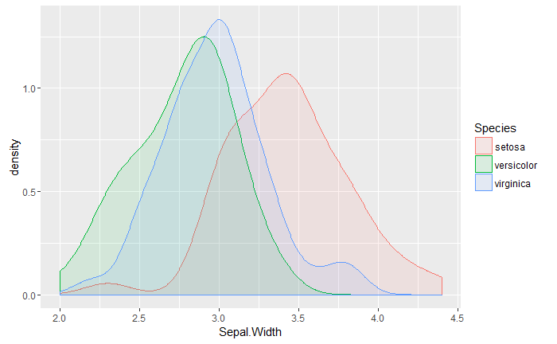

```r
ggplot(data=iris, aes(x=Sepal.Width, color=Species, fill=Species)) + geom_density(alpha=0.1) + scale_fill_discrete()
```

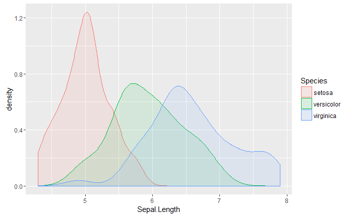

```r
ggplot(data=iris, aes(x=Sepal.Length, color=Species, fill=Species)) + geom_density(alpha=0.1) + scale_fill_discrete()
```

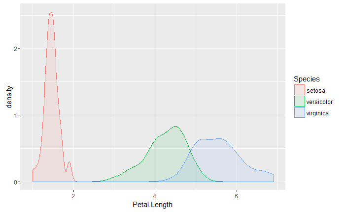

```r
ggplot(data=iris, aes(x=Petal.Length, color=Species, fill=Species)) + geom_density(alpha=0.1) + scale_fill_discrete()
```

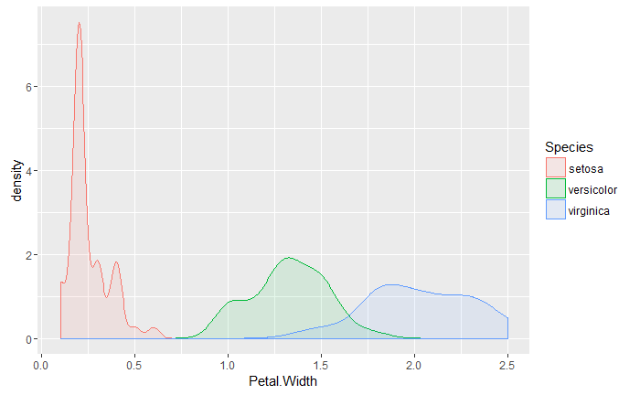

```r
ggplot(data=iris, aes(x=Petal.Width, color=Species, fill=Species)) + geom_density(alpha=0.1) + scale_fill_discrete()
```

### Jedna zmienna objaśniająca

Załóżmy, że

$f_k(x)$ ma rozkład normalny z parametrami $\mu_k$ oraz $\sigma_k^2$

```r
model<-naiveBayes(Species~Sepal.Width, data=iris)
model$apriori
```

```
Y
    setosa versicolor  virginica
        50         50         50
```

```r
model$tables
```

```
$Sepal.Width
            Sepal.Width
Y             [,1]      [,2]
  setosa     3.428 0.3790644
  versicolor 2.770 0.3137983
  virginica  2.974 0.3224966
```

```r
#Wartość funkcji rozkładu gęstości pstwa dla rozkładu normalnego
# Dla wartości Sepal.Width = 3.5 mamy odpowiednie wartości rozkładów
P_Species<- dnorm(c(3.5,3.5,3.5), mean=model$tables$Sepal.Width[,1], sd=model$tables$Sepal.Width[,2])/
                sum(dnorm(c(3.5,3.5,3.5), mean=model$tables$Sepal.Width[,1], sd=model$tables$Sepal.Width[,2]))
pred<-predict(model, iris, type="raw")
head( cbind (iris$Sepal.Width, pred ))
```

```
            setosa  versicolor  virginica
[1,] 3.5 0.7149691 0.058751495 0.22627942
[2,] 3.0 0.2014921 0.351961933 0.44654596
[3,] 3.2 0.3748284 0.212181702 0.41298992
[4,] 3.1 0.2782470 0.281142856 0.44061017
[5,] 3.6 0.8074072 0.032710174 0.15988265
[6,] 3.9 0.9566028 0.003833692 0.03956354
```

### Wiele zmiennych objaśniajacych

```r
model<-naiveBayes(Species~., data=iris)
model$apriori
model$tables


pred_Species<-predict(model, iris)
head(cbind(iris, pred_Species ))

table(iris$Species, pred_Species)


pred<-predict(model, iris, type="raw")
head(cbind(iris, pred ))
```

[output not shown]